# R Notebook

Week 6 day 4

Hypothesis testing One sample test using a mean

```r
library(tidyverse)
library(janitor)
library(infer)
```

```r
books <- read_csv("books.csv") %>%
  clean_names()
```

```r
books_tidy <- books %>%
  filter(!is.na(average_rating)) %>%
  rename(num_pages = number_num_pages)

glimpse(books_tidy)
```

```r
books_tidy %>%
  ggplot(aes(x = average_rating)) +
  geom_histogram(col = "white")
```

```r
books_tidy %>%
  ggplot(aes(x = average_rating)) +
  geom_boxplot()
```

In 2016, the mean rating was 3.93. Is the 2020 data statistically different?

The question is framed in terms of two competing questions: H0(H naught) - null hypothesis. The skeptical stance / nothing has changed. E.g. our null hypothesis is that the mean is the same as the as the historic mean.

The competing - Ha(alternative). The current mean is not the same as the historic mean.

```r
observed_stat <- books_tidy %>%
  summarise(mean_rating = mean(average_rating))

observed_stat
```

| mean_rating |
| --- |
| 3.937568 |

Generating the null sampling distribution - very similar to code for CI’s

```r
null_distribution <- books_tidy %>%
  specify(response = average_rating) %>%
  # extra line added for the null sampling - telling R what our null hypothesis is
  hypothesise(null = "point", mu = 3.93) %>%
  generate(reps = 10000, type = "bootstrap") %>%
  calculate(stat = "mean")
```

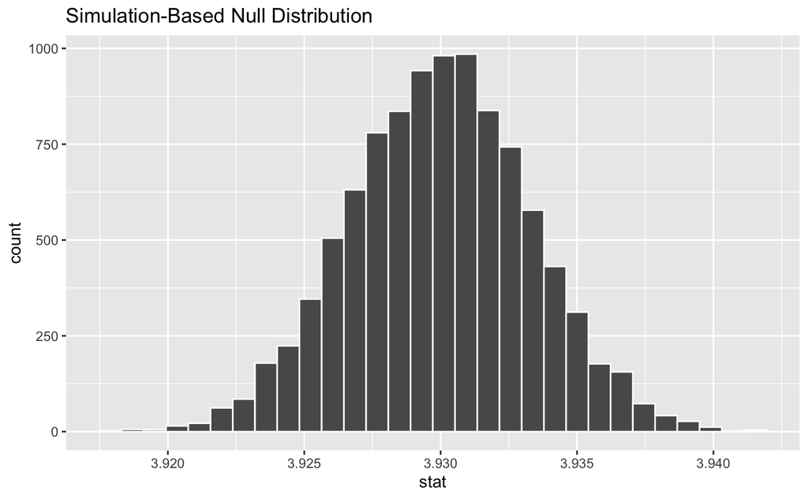

```r
null_distribution %>%
  visualise(bins = 30)
```

Visualise observed statistic (the mean for the sample)

```r
observed_stat
```

| mean_rating |
| --- |
| 3.937568 |

```r
NA
NA
```

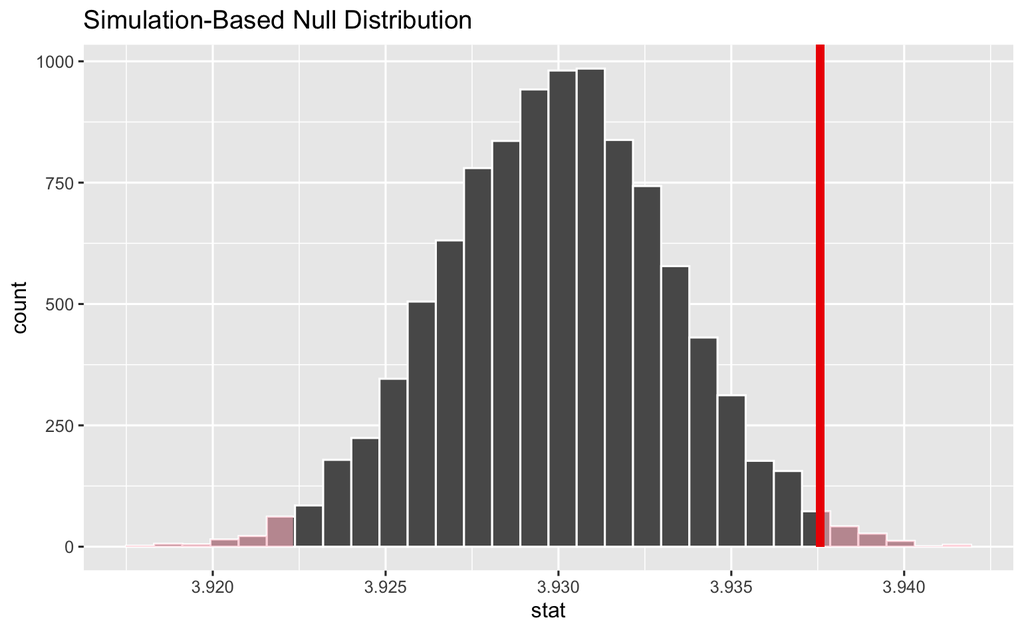

```r
null_distribution %>%
  visualise(bins = 30) +
  shade_p_value(obs_stat = observed_stat$mean_rating,
                direction = "both"
                )
```

Caclulate the p value

```r
p_value <- null_distribution %>%
  get_p_value(obs_stat = observed_stat$mean_rating,
              direction = "both"
              )
p_value
```

| p_value |
| --- |
| 0.0206 |

```r
NA
```

There is sufficient data to reject the null hypothesis.

# Lesson 2

One sample test using a proportion

Question: Does the proportion of books in the database that lack text reviews differ significantly from 7%?

Null hypothesis: the pop proportion that don’t have a text review = 7% Alt hypothesis: the pop proportion that don’t have a text review =/= 7%

proportion of books with no text review

```r
observed_prop_stat <- books_prop %>%
  group_by(text_reviews_count) %>%
  summarise(prop = n()/nrow(books_prop)) %>%
  filter(text_reviews_count == 0) %>%
  pull()


# the most common is 0 = 6.5% - this is the sample proportion
```

```r
books_prop_tidy <- books_prop %>%
  mutate(text_reviews_flag = if_else(text_reviews_count > 0,
                                     "text_review",
                                     "no_text_review"))

books_prop_tidy
```

generate null distribution

```r
null_distribution_books_prop <- books_prop_tidy %>%
  specify(response = text_reviews_flag, success = "no_text_review") %>%
  hypothesise(null = "point", p = 0.07) %>%
  generate(reps = 5000, type = "draw") %>%
  calculate(stat = "prop")

head(null_distribution_books_prop)
```

```r
null_distribution_books_prop %>%
  visualise(bins = 30)
```

now we will overlay the actual statistic

```r
observed_prop_stat <- books_prop_tidy %>%
  specify(response = text_reviews_flag,
          success = "no_text_review",
  ) %>%
  calculate(stat = "prop")

observed_prop_stat
```

```r
null_distribution_books_prop %>%
  visualise(bins = 30) +
  shade_p_value(obs_stat = observed_prop_stat,
                direction = "both")
```

[output not shown]

The null hypothesis can be rejected

Task

proportion of books published in french

```r
fre_prop_books <- books %>%
  group_by(language_code) %>%
  summarise(prop = n()/nrow(books)) %>%
  filter(language_code == "fre")

books_fre_tidy <- books %>%
  mutate(fre_lang_flag = if_else(language_code == "fre",
                           "fre_lang",
                           "not_fre_lang"))
```

creating the null distribution

```r
null_distr_fre_prop <- books_fre_tidy %>%
  specify(response = fre_lang_flag, success = "fre_lang") %>%
  hypothesise(null = "point", p = 0.015) %>%
  generate(reps = 5000, type = "draw") %>%
  calculate(stat = "prop")
```

visualise

```r
null_distr_fre_prop %>%
  visualise(bins = 30)
```

```r
observed_fre_stat <- books_fre_tidy %>%
  specify(response = fre_lang_flag,
          success = "fre_lang") %>%
  calculate(stat = "prop")
observed_fre_stat
```

```
Response: fre_lang_flag (factor)
```

| stat |
| --- |
| 0.01472326 |

```r
null_distr_fre_prop %>%
  visualise(bins = 30) +
  shade_p_value(obs_stat = observed_fre_stat,
                direction = "left")
```

[output not shown]

# Lesson 3

Two sample T-tests

Can be paired Can be independent

First question to ask for a two-sample test, is are the individual observations independent or paired? They are independent if: there is no connection (e.g. where there is a control group and test group) They are paired if: If there is a connection with one, and only one observation in the other sample. E.g. two sets of cohort before and after treatment

# For independent samples

In a independent case (example), we will compare the mean of two prices, and there is no restriction that the samples have to be the same size

```r
nice <- read_csv("nice.csv")
algarve <- read_csv("algarve.csv")
```

[output not shown]

```r
apart_prices %>%
  group_by(location) %>%
  summarise(n = n())
```

```r
apart_prices %>%
  ggplot(aes(x = location, y = price)) +
  geom_boxplot()
```

```r
null_distr <- apart_prices %>%
  specify(price ~ location) %>%
  hypothesise(null = "independence") %>%
  generate(reps = 1000, type = "permute") %>%
  calculate(stat = "diff in means",
            order = c("algarve", "nice"))

head(null_distr)
```

```
Response: price (numeric)
Explanatory: location (factor)
Null Hypothesis: independence
```

| replicate | stat |
| --- | --- |
| 1 | -57.10000 |
| 2 | 4.27500 |
| 3 | -77.05833 |
| 4 | 35.69167 |
| 5 | 106.19167 |
| 6 | -20.10000 |

```r
obs_stat_apart <- apart_prices %>%
  specify(price ~ location) %>%
  calculate(stat = "diff in means",
            order = c("algarve", "nice"))

obs_stat_apart
```

```
Response: price (numeric)
Explanatory: location (factor)
```

| stat |
| --- |
| 251.4 |

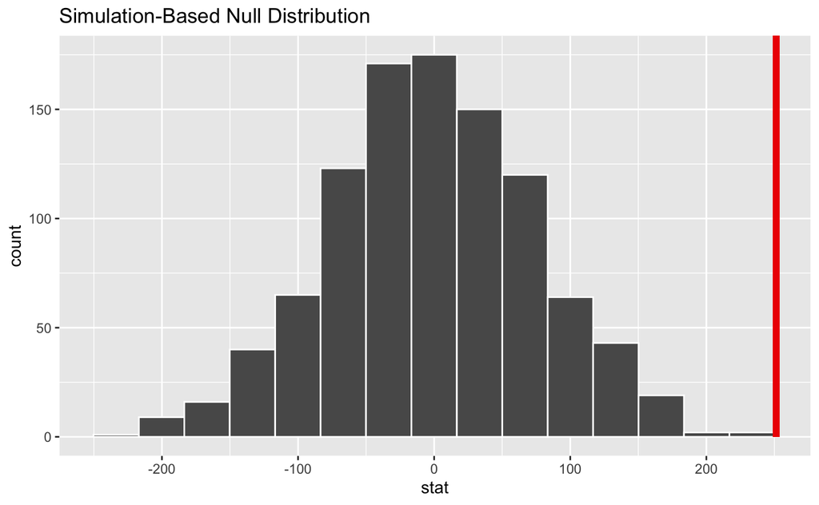

```r
null_distr %>%
  visualise() +
  shade_pvalue(obs_stat = obs_stat_apart,
                direction = "right")
```

```r
p_value_apart <- null_distr %>%
  get_p_value(obs_stat = obs_stat_apart,
              direction = "right")
p_value_apart
```

| p_value |
| --- |
| 0 |